# Write Down All The Things

Kui Xue

2022-11-10

> “I don’t need to write that down, I’ll remember it” is the biggest lie you can tell yourself! Write down everything you do — even if it doesn’t work. This includes meeting notes, method details, code annotations, among other things.

## 0.1 Statistic

[**Repeated measures ANOVA**](https://www.datanovia.com/en/lessons/repeated-measures-anova-in-r/)

判断被试内因子是否存在交互作用，首先看是否满足球形假设p>.05。若不满足，需校正。

**One-way repeated measures ANOVA**

within-subjects factor (here time)

```r
library(tidyverse)
library(ggpubr)
library(rstatix)
data('selfesteem', package = 'datarium')
head(selfesteem, 3)
```

```
## # A tibble: 3 × 4
##      id    t1    t2    t3
##   <int> <dbl> <dbl> <dbl>
## 1     1  4.01  5.18  7.11
## 2     2  2.56  6.91  6.31
## 3     3  3.24  4.44  9.78
```

```r
self1= selfesteem %>%
  pivot_longer(-1, names_to = 'time', values_to = 'score')
head(self1, 3)
```

```
## # A tibble: 3 × 3
##      id time  score
##   <int> <chr> <dbl>
## 1     1 t1     4.01
## 2     1 t2     5.18
## 3     1 t3     7.11
```

```r
# assumption 1: identify outliers
self1 %>%
  group_by(time) %>%
  identify_outliers(score)
```

```
## # A tibble: 2 × 5
##   time     id score is.outlier is.extreme
##   <chr> <int> <dbl> <lgl>      <lgl>
## 1 t1        6  2.05 TRUE       FALSE
## 2 t2        2  6.91 TRUE       FALSE
```

```r
# assumption 2: normality
self1 %>%
  group_by(time) %>%
  shapiro_test(score)
```

```
## # A tibble: 3 × 4
##   time  variable statistic     p
##   <chr> <chr>        <dbl> <dbl>
## 1 t1    score        0.967 0.859
## 2 t2    score        0.876 0.117
## 3 t3    score        0.923 0.380
```

*Note that*, if your sample size is greater than 50, the normal QQ plot is preferred because at larger sample sizes the Shapiro-Wilk test becomes very sensitive even to a minor deviation from normality.

```r
# assumption 3: sphericity
anova_test(self1, dv= score, wid= id, within= time)
## ANOVA Table (type III tests)
##
## $ANOVA
##   Effect DFn DFd      F        p p<.05   ges
## 1   time   2  18 55.469 2.01e-08     * 0.829
##
## $`Mauchly's Test for Sphericity`
##   Effect     W     p p<.05
## 1   time 0.551 0.092
##
## $`Sphericity Corrections`
##   Effect  GGe      DF[GG]    p[GG] p[GG]<.05   HFe      DF[HF]    p[HF]
## 1   time 0.69 1.38, 12.42 2.16e-06         * 0.774 1.55, 13.94 6.03e-07
##   p[HF]<.05
## 1         *
```

```r
# pairwise comparisons; post hoc test
self1 %>%
  pairwise_t_test(score ~ time, paired = TRUE,
    p.adjust.method = "bonferroni")
```

```
## # A tibble: 3 × 10
##   .y.   group1 group2    n1    n2 statistic    df           p    p.adj p.adj.s…¹
## * <chr> <chr>  <chr>  <int> <int>     <dbl> <dbl>       <dbl>    <dbl> <chr>
## 1 score t1     t2        10    10     -4.97     9 0.000772    0.002    **
## 2 score t1     t3        10    10    -13.2      9 0.000000334 0.000001 ****
## 3 score t2     t3        10    10     -4.87     9 0.000886    0.003    **
## # … with abbreviated variable name ¹p.adj.signif
```

**Two-way repeated measures ANOVA**

The main goal of two-way and three-way repeated measures ANOVA is, respectively, to evaluate if there is a statistically significant interaction effect between two and three within-subjects factors in explaining a continuous outcome variable.

```r
data('selfesteem2', package = 'datarium')
set.seed(10)
selfesteem2 %>% sample_n_by(treatment, size= 2)
```

```
## # A tibble: 4 × 5
##   id    treatment    t1    t2    t3
##   <fct> <fct>     <dbl> <dbl> <dbl>
## 1 11    ctr          92    92    91
## 2 9     ctr          95    91    84
## 3 10    Diet         90    93    95
## 4 7     Diet         90    87    87
```

```r
self2= selfesteem2 %>%
  pivot_longer(-1:-2, names_to = 'time', values_to = 'score')
```

Check assumptions for outliers and normality using vars ‘treatment’ and ‘time’ to group by

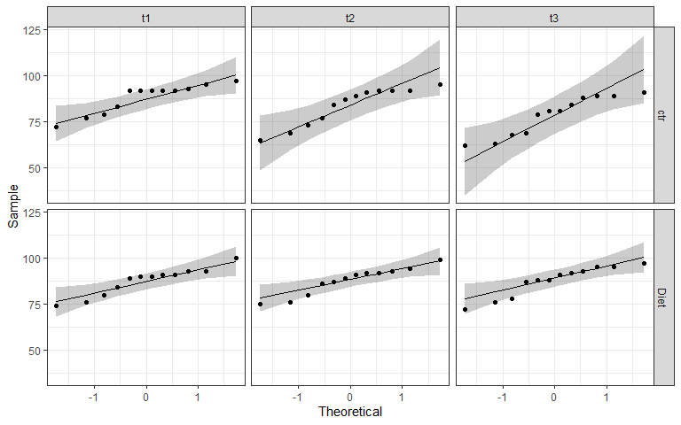

```r
self2 %>%
  ggqqplot('score')+
  facet_grid(vars(treatment), vars(time))+
  theme_bw()
```

```r
self2 %>%
  anova_test(dv= score, wid= id, within= c(treatment, time))
## ANOVA Table (type III tests)
##
## $ANOVA
##           Effect DFn DFd      F        p p<.05   ges
## 1      treatment   1  11 15.541 2.00e-03     * 0.059
## 2           time   2  22 27.369 1.08e-06     * 0.049
## 3 treatment:time   2  22 30.424 4.63e-07     * 0.050
##
## $`Mauchly's Test for Sphericity`
##           Effect     W     p p<.05
## 1           time 0.469 0.023     *
## 2 treatment:time 0.616 0.089
##
## $`Sphericity Corrections`
##           Effect   GGe      DF[GG]    p[GG] p[GG]<.05   HFe      DF[HF]
## 1           time 0.653 1.31, 14.37 5.03e-05         * 0.705 1.41, 15.52
## 2 treatment:time 0.723  1.45, 15.9 1.25e-05         * 0.803 1.61, 17.66
##      p[HF] p[HF]<.05
## 1 2.81e-05         *
## 2 4.82e-06         *
```

There is a significant interaction (p= 4.63e-07), indicates that effect of one factor (e.g., treatment) on y depends on the level of the other factor (e.g., time).

In the situation where we can separate two-way interaction into:

- **Simple main effect**
- **Simple pairwise comparison**: if simple main effect is significant, run pairwise comparisons to determine which groups are different.

**Procedure for a significant two-way interaction**

```r
# Effect of treatment at each time point
self2 %>%
  group_by(time) %>%
  anova_test(dv= score, wid= id, within= treatment) %>%
  adjust_pvalue(method = 'bonferroni')

self2 %>%
  group_by(time) %>%
  pairwise_t_test(score ~ treatment, paired = TRUE,
    p.adjust.method = "bonferroni")
```

Note that, the treatment factor variable has only two levels (“ctr” and “Diet”); thus, ANOVA test and paired t-test will give the same p-values.

**Procedure for non-significant two-way interaction**

If the interaction is not significant, you need to interpret the main effects for each of the two variables: treatment and time.

```r
# comparisons for treatment variable
self2 %>%
  pairwise_t_test(score ~ treatment, paired = TRUE,
    p.adjust.method = "bonferroni")
# comparisons for time variable
self2 %>%
  pairwise_t_test(score ~ time, paired = TRUE,
    p.adjust.method = "bonferroni")
```

**Three-way repeated measures ANOVA**

```r
data('weightloss', package = 'datarium')
w1= weightloss %>%
  pivot_longer(-id:-exercises, names_to = 'time', values_to = 'score')

w1 %>%
  anova_test(dv= score, wid= id, within = c(diet, exercises, time))
```

[output not shown]

Note that, if the three-way interaction is not statistically significant, you need to consult the two-way interactions in the output.

- Simple two-way interaction, run two-way interaction at each level of third var
- Simple main effect, run one-way model at each level of second var, and
- pairwise comparison, if necessary

You are free to decide which two variables will form the simple two-way interactions and which variable will act as the third (moderator) variable.

```r
# post-hoc test
w1 %>%
  group_by(diet) %>%
  anova_test(dv= score, wid= id, within= c(exercises, time)) %>%
  get_anova_table()
```

```
## # A tibble: 6 × 8
##   diet  Effect           DFn   DFd     F        p `p<.05`   ges
##   <fct> <chr>          <dbl> <dbl> <dbl>    <dbl> <chr>   <dbl>
## 1 no    exercises          1    11 72.8  3.53e- 6 "*"     0.526
## 2 no    time               2    22 71.7  2.32e-10 "*"     0.587
## 3 no    exercises:time     2    22 28.9  6.92e- 7 "*"     0.504
## 4 yes   exercises          1    11 13.4  4   e- 3 "*"     0.038
## 5 yes   time               2    22 20.5  9.3 e- 6 "*"     0.49
## 6 yes   exercises:time     2    22  2.57 9.9 e- 2 ""      0.06
```

Note that, it’s recommended to adjust the p-value for multiple testing. One common approach is to apply a Bonferroni adjustment to downgrade the level at which you declare statistical significance.

This can be done by dividing the current level you declare statistical significance at (i.e., p < 0.05) by `the number of simple two-way interaction you are computing` (i.e., 2).

Thus, you only declare a two-way interaction as statistically significant when p < 0.025 (i.e., p < 0.05/2). Applying this to our current example, we would still make the same conclusions.

A statistically significant simple two-way interaction can be followed up with simple simple main effects.

We will only need to consider the result of the simple simple main effect analyses for the `“diet no” trial` as this was the only simple two-way interaction that was statistically significant

```r
w1 %>%
  group_by(diet, exercises) %>%
  anova_test(dv= score, wid= id, within= time) %>%
  get_anova_table() %>%
  filter(diet== "no")  # interaction only existing in 'diet no' trial
```

```
## # A tibble: 2 × 9
##   diet  exercises Effect   DFn   DFd     F        p `p<.05`   ges
##   <fct> <fct>     <chr>  <dbl> <dbl> <dbl>    <dbl> <chr>   <dbl>
## 1 no    no        time       2    22  1.32 2.86e- 1 ""      0.075
## 2 no    yes       time       2    22 78.8  9.3 e-11 "*"     0.801
```

```r
# compute simple pairwise comparison
w1 %>%
  filter(diet== "no" & exercises== "yes") %>%
  pairwise_t_test(score ~ time, paired = TRUE, p.adjust.method = "bonferroni")
```

```
## # A tibble: 3 × 10
##   .y.   group1 group2    n1    n2 statistic    df             p    p.adj p.adj…¹
## * <chr> <chr>  <chr>  <int> <int>     <dbl> <dbl>         <dbl>    <dbl> <chr>
## 1 score t1     t2        12    12     -5.31    11 0.000247       7.41e-4 ***
## 2 score t1     t3        12    12    -16.6     11 0.00000000402  1.21e-8 ****
## 3 score t2     t3        12    12     -6.03    11 0.0000857      2.57e-4 ***
## # … with abbreviated variable name ¹p.adj.signif
```

```r
# comparison for 'diet yes' trial; non-significant interaction
w1 %>%
  filter(diet== "yes") %>%
  pairwise_t_test(score ~ time, paired = TRUE, p.adjust.method = 'bonferroni')
```

```
## # A tibble: 3 × 10
##   .y.   group1 group2    n1    n2 statistic    df            p     p.adj p.adj…¹
## * <chr> <chr>  <chr>  <int> <int>     <dbl> <dbl>        <dbl>     <dbl> <chr>
## 1 score t1     t2        24    24     -3.50    23 0.002          6   e-3 **
## 2 score t1     t3        24    24     -8.20    23 0.0000000282   8.46e-8 ****
## 3 score t2     t3        24    24     -3.34    23 0.003          8   e-3 **
## # … with abbreviated variable name ¹p.adj.signif
```